# Reproducibility

## You will learn…

> 1. RStudio Projects  
> 2. R Markdown  
> 3. R Notebooks

Download RStudio Preview from https://www.rstudio.com/products/rstudio/download/preview

## RStudio Projects

*"Organization is what you do before you do something, so that when you do it, it is not all mixed up."* - A.A. Milne

## Using Projects

> RStudio projects make it straightforward to divide your work into multiple contexts, each with their own working directory, workspace, history, and source documents.

## Let's create a project

> **File** » **New Project**

[figure not shown]

## So what's different?

[figure not shown]

## So what's different?

### When a project is opened:

- A new R session is started
- The .Rprofile file in the project's main directory is sourced
- The .RData file in the project's main directory is loaded
- The .Rhistory file in the project's main director is loaded
- The current working directory is set to the project directory
- Previously edited source docs are restored to the editor tab
- Other RStudio settings (active tabs, splitter positions, etc) are restored

> *We can also work with multiple projects at one time*

## Set Project Options

> There are some per-project customization options

> **Tools** » **Project Options**

[figure not shown]

## Your Turn!

> If you have not already done so create a project for today's session

## R Markdown

*Fully reproducible approach to turn your analyses into high quality documents, reports, presentations and dashboards.*

## Using R Markdown

> R Markdown allows you to turn your analyses into high quality documents, reports, presentations and dashboards.

[figure not shown]

## How does it work?

1. Creating documents with R Markdown starts with an `.Rmd` file that contains a combination of text and R code chunks
2. The .Rmd file is fed to `knitr`, which executes all of the R code chunks and…
3. creates a new markdown (`.md`) document with the output
4. `pandoc` then processes the .md file to create a finished…
5. web page, PDF, Word document, slide show, etc.

## Say what?

[figure not shown]

## Okay, one more time, how does it work?

[figure not shown]

## Let's create a document

> **File** » **New File** » **R Markdown**

[figure not shown]

## Let's create a document

[figure not shown]

## Your Turn!

> 1. Render (*"knit"*) the document to HTML, PDF, Word  
> 2. Notice the changes to the YAML (aka *header*) in the `.Rmd` file  
> 3. Compare the output with the `.Rmd` file  
> 4. Find the outputs on your computer

## Markdown syntax

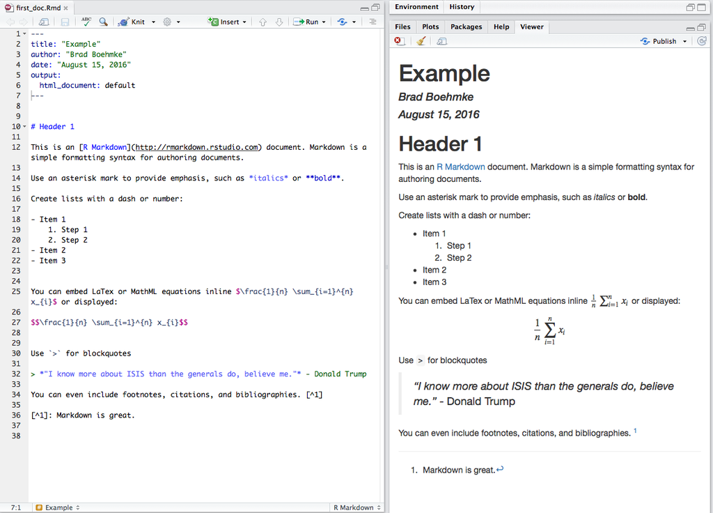

## Embedding code

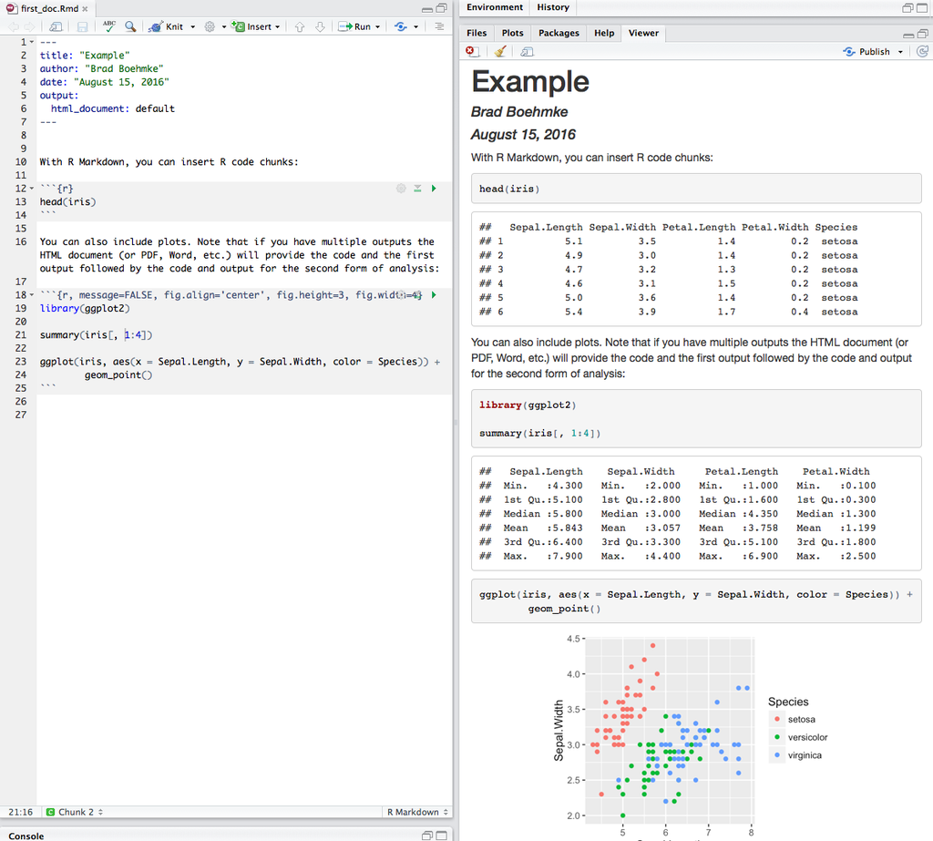

## Demo

> Open the  
> `06-R-Markdown-Demo.Rmd`  
> file

## Your Turn!

> Re-create the following R Markdown document located at:

> http://rpubs.com/bradleyboehmke/rmarkdown_replication

## R Notebooks

*Interactive execution mode for R Markdown documents.*

## Why so Special?

> 1. Creates greater interactivity while creating your document  
> 2. Easy to share your notebook directly  
> 3. When complete, knit to the publication format desired

## Let's create a document

> **File** » **New File** » **R Notebook**

[figure not shown]

## Demo

> Open the  
> `06-R-Notebook-Demo.Rmd`  
> file